# Question to Answer and Key Insight:

What major business insight for a movie studio can be gained by undertaking a relatively basic exploratory look at the movies data?

As the initial analysis and the graphics below show, movies whose 'num_voted_users' and 'movie_facebook_likes' are high have a higher chance of being profitable. In contrast actor and director Facebook likes and other metrics might not have a similar or substantial impact.

# Note on Missing Values and Inference:

In the cell below is basic Python code to read in the file into a Pandas dataframe.

A column named 'count' is added to aid analysis in some instances. An additional variable called 'Net' ('gross' - 'budget') has also been added for each movie.

In light of the business focus of the question a focal point of this analysis is financial data for each movie in the data set, specifically the data in the 'gross' and 'budget' columns and in the newly created 'Net' column.

As the print out from the cell below shows there are 759 out of 4873 movies for which the 'gross' value is missing while the 'budget' value is missing for 388 movies. As the print out shows, 3849 movies have both values and thus also the 'Net' value. Furthermore, some of the other variables focused on below have a small number of values missing.

Since this is an initial exploratory analysis, no steps are being taken to deal with missing values and there is an assumption being made that the movies with missing values are not from a separate population than the movies that have all the relevant values. A deeper analysis comparing movies with missing values against those without might reveal differences in the two populations and require additional corrective steps, but that issue is out of the scope of this analysis. In light of the missing values, however, the conclusions of this analysis should thus be treated as tentative and preliminary.

Statistical inference techniques are not being used since there is limited information on how this data was collected and whether it is representative of a broader population. The data is thus being used as that of a population, however with an interest in applying the insight to future decisions.

```python
import matplotlib.pyplot as plt
import matplotlib
matplotlib.style.use('ggplot')

import numpy as np
import pandas as pd
import csv

Movies = pd.read_csv('movies.csv')

#Creating 'count' and 'Net' colums
Movies['count'] = 1
Movies['Net'] = Movies['gross'] - Movies['budget']

#Checking for missing values
Movies['GrossMissing'] = Movies['gross'].isnull()
Movies['BudgetMissing'] = Movies['budget'].isnull()
Movies['NetMiss'] = Movies['Net'].isnull()

print (Movies.groupby(['GrossMissing','BudgetMissing','NetMiss'])['count'].agg([np.sum]))
```

```
                                     sum
GrossMissing BudgetMissing NetMiss
False        False         False    3849
             True          True      265
True         False         True      636
             True          True      123
```

# Note on Older Movies:

Since the movie release years span a long timeframe, inflation adjusted gross and budget data is most relevant if one is to gain insight into how much each movie made in current dollars. However, even without such an adjustment, one can see whether a movie is profitable and see the relationship of this basic metric with other variables such as current Facebook likes and IMDB scores.

Finally, most of the movies in the data set were released after the advent of the internet, but many were created before Facebook and some before the IMDB. The Facebook likes and IMDB data in the case of all movies is presumably a reflection of their popularity during the current period or during a specific timeframe rather than of when each movie was released. Thus these metrics serve as an imperfect measure of popularity at release when most movie theater earnings take place.

In creating a useable model in future a deeper analysis and adaptation of the data to improve predictions would be needed and thus the current insights should be treated as tentative leads used to guide further investigation and model building.

# Correlation with Net:

A quick look at the correlations of the 'Net' variable (not shown here) with other variables shows relatively high correlations for the following variables:

```
imdb_score                            0.176723

num_voted_users                       0.384649

movie_facebook_likes                  0.179455

director_facebook_likes               0.085370

actor_2_facebook_likes                0.100406

actor_3_facebook_likes                0.127186
```

Correlations only focus on linear relationships and do not provide comprehensive insight into the data but can be useful for an initial analysis. Furthermore, correlation does not necessarily imply any specific causal link and any high correlation needs to be carefully evaluated to ensure that there is indeed an explanation for it and it is not simply spurious correlation.

Although 'budget' and 'gross' also have high correlations with 'Net' they are not being focused on since they constitute the inputs for the 'Net' variable and thus are expected to have a relatively high correlation.

In the case of 'budget' the high negative correlation speaks to the idea that the lower the cost the higher the potential profit or yield -- something relatively intuitive also confirmed by data. 'title_year' also has a relatively high correlation, presumably a reflection of the price level going up over time, but this is not a focus since it is not a variable on which a movie studio has much control if the studio is already committed to making a certain number of movies every year.

# Plots of Movie Focused Metrics

Code from the cell below displays two visuals whose x axis metrics are a function of the quality and viewer enthusiasm for a specific movie. In all the graphics below, the regression line is being used only for visual illustrative purposes rather than as part of building a model thus negating the need for checking whether the data abides to requirements for regression models.

Such movie focused metrics are distinct from the Facebook likes for a particular director or an actor in that such individuals are typically affiliated with multiple movies or entertainment areas and the Facebook likes for them are probably not simply a function of work on a particular movie. The first scatter plot below shows the relationship between 'num_voted_users' (x axis) and 'Net' (y axis)(Correlation: 0.384649) and the second scatter plot shows the relationship between 'movie_facebook_likes' (x axis) and 'Net' (y axis)(Correlation: 0.179455).

Although neither pair has a particularly strong correlation, the visuals show that as the numbers on the x axis increase the odds of a movie having a positive 'Net' increase, particularly in the case of 'num_voted_users', a metric presumably derived from the number of IMDB users voting for a movie.

The movie focused metrics are not likely to be available in the planning phases of movie production and cannot serve as a guide at that time. They might however constitute a component of a earnings forecasting model around the time of movie release.

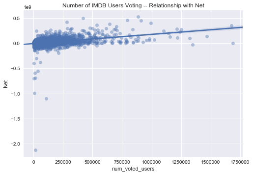

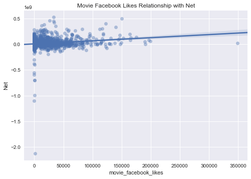

```python
import seaborn as sns
sns.regplot(x = 'num_voted_users', y = 'Net', data = Movies, scatter_kws={'alpha':0.4})
plt.title('Number of IMDB Users Voting -- Relationship with Net')
plt.show()
sns.regplot(x = 'movie_facebook_likes', y = 'Net', data = Movies, scatter_kws={'alpha': 0.4})
plt.title('Movie Facebook Likes Relationship with Net')
plt.show()
```

# Plots of Personnel Focused Metrics

Code from the cell below displays two visuals whose x axis metrics are a function of the Facebook likes for a director or actor of a movie.

The first scatter plot below shows the relationship between 'director_facebook_likes' (x axis) and 'Net' (y axis) (Correlation: 0.085370) and the second scatter plot shows the relationship between 'actor_3_facebook_likes' (x axis) and 'Net' (y axis) (Correlation:0.127186).

These metrics focus on individuals who are likely affiliated with multiple movies. Their number of Facebook likes, might be influenced by the specific movie in the database, but probably reflects a larger body of their work. The metric might also be a proxy for the actor or director's popularity.

In the case of the actor data for some movies in the database, the main lead actor is not noted as one of the actors (for. eg. 'Skyfall') suggesting that any analysis resulting from this data should only be viewed as a first step and be further validated. A deeper look at the issue is outside the scope of this analysis and in this case the actor data is being considered broadly reflective of the major cast in the movie.

The key takeaway from the plots is that neither pair has a particularly strong correlation. Although there appears to be a slight increase in the odds of a positive net as the number of Facebook likes increases, the link seems tenuous and less pronounced than in the case of the movie focused metrics above.

Correlation and visual data underpin the insights in this analysis. A deeper analysis would confirm such insights by analyzing what percentage of movies are profitable at each interval for the four metrics plotted above -- for e.g. For 'actor_3_facebook_likes' one would calculate the percentage of profitable movies for each interval of 5000 likes to see if the percentage increases.

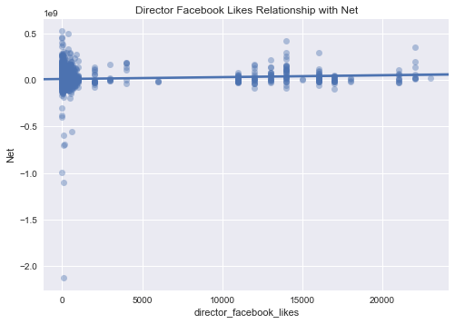

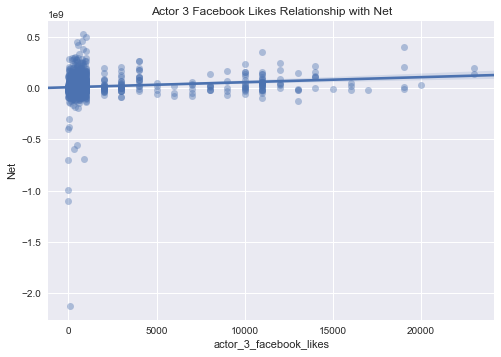

```python
import seaborn as sns
sns.regplot(x = 'director_facebook_likes', y = 'Net', data = Movies, scatter_kws={'alpha':0.4})
plt.title('Director Facebook Likes Relationship with Net')
plt.show()
sns.regplot(x = 'actor_3_facebook_likes', y = 'Net', data = Movies, scatter_kws={'alpha':0.4})
plt.title('Actor 3 Facebook Likes Relationship with Net')
plt.show()
```

# Key Takeaways

A key insight from the above is that the Facebook likes for the actors and director of the movie in and of themselves might not necessarily maximize the gross and should not be weighed too strongly when making decisions on casting and director.

The focus should be on making a high quality product with high viewer enthusiasm as reflected in the 'num_voted_users' and 'movie_facebook_likes' and casting and director decisions focused on maximizing the movie quality and viewer enthusiasm might lead to a higher gross.

Although the popularity of the cast and director is likely to have some impact on the quality of the movie and viewer enthusiasm, the movie focused metrics are distinct and maximizing them would likely require a somewhat different strategy than maximizing the personnel focused metrics.